# Personal activity data

Kollanyi

July 17, 2015

Before you start: Please unzip the activity file and set your working directory according to its location.

First thing first, load the data.

```r
activity <- read.csv('activity.csv', sep=",", na.strings = "NA",
                  colClasses =c("numeric", "Date", "numeric"))
```

What is mean total number of steps taken per day?

Make a histogram of the total number of steps taken each day.

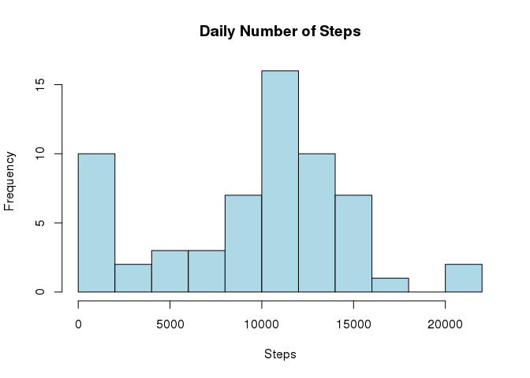

```r
ndStep <- tapply(activity$steps, activity$date, function(x) sum(x, na.rm = TRUE))
hist(ndStep, breaks = 15, col="lightblue", main="Daily Number of Steps",  xlab="Steps")
```

Calculate the mean and median of the total number of steps taken per day.

```r
ndStepMean <-mean(ndStep, na.rm = TRUE)
ndStepMean
```

```
## [1] 9354.23
```

```r
ndStepsMedian<- median(ndStep,na.rm = TRUE)
ndStepsMedian
```

```
## [1] 10395
```

Make a time series plot (i.e. type = “l”) of the 5-minute interval (x-axis) and the average number of steps taken, averaged across all days (y-axis)

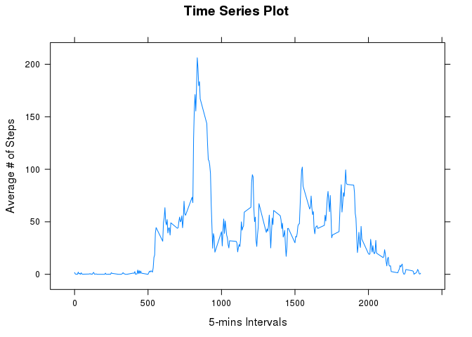

```r
library(lattice)
aggActivity <- aggregate(activity$steps ~ activity$interval, FUN = "mean",  na.rm=T)
names(aggActivity) <- c("interval","avesteps")
xyplot(aggActivity$avesteps ~ aggActivity$interval, type = "l", xlab = "5-mins Intervals", ylab =  "Average # of Steps", main = "Time Series Plot")
```

```r
max <- which.max(aggActivity$avesteps)
```

Calculate and report the total number of missing values in the dataset (i.e. the total number of rows with NAs)

```r
table(is.na(activity$steps))["TRUE"]
```

```
## TRUE
## 2304
```

Create a new dataset that is equal to the original dataset but with the missing data filled in

```r
library(zoo)
miss <- na.aggregate(activity$steps)
activity -> activitynomiss
activitynomiss$steps <- miss
```

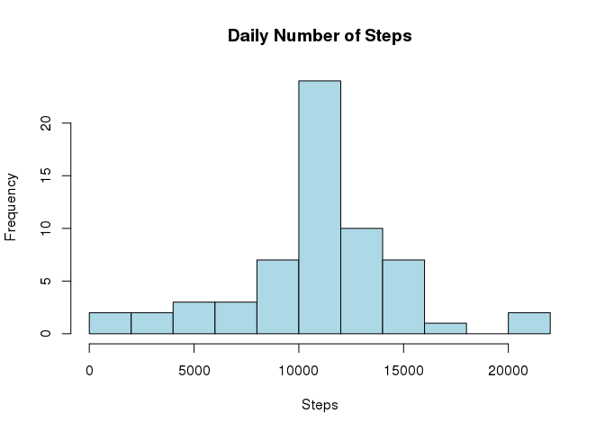

```r
missStep <- tapply(activitynomiss$steps, activitynomiss$date, function(x) sum(x, na.rm = TRUE))
hist(missStep, breaks = 15, col="lightblue", main="Daily Number of Steps",  xlab="Steps")
```

Calculate the mean and median of the total number of steps taken per day.

```r
missStepMean <-mean(missStep, na.rm = TRUE)
missStepMean
```

```
## [1] 10766.19
```

```r
missStepsMedian<- median(missStep,na.rm = TRUE)
missStepsMedian
```

```
## [1] 10766.19
```